# 金融数据分析报告

P02a 作业 · 许博东 · 学号 25210269 · 2026年5月

## 一、描述性统计

10只股票日收益率（对数收益率）的描述性统计量，年化处理（252个交易日）：

| 股票 | 代码 | 行业 | 年化均值 | 年化波动率 | 偏度 | 峰度 | 最大回撤 |
| --- | --- | --- | --- | --- | --- | --- | --- |
| 工商银行 | 601398 | 银行 | 0.0884 | 0.1613 | 0.4542 | 5.8554 | -0.2240 |
| 招商银行 | 600036 | 银行 | 0.0370 | 0.2736 | 0.2718 | 3.2840 | -0.5464 |
| 比亚迪 | 002594 | 汽车 | 0.2895 | 0.4282 | 0.3132 | 2.1601 | -0.5605 |
| 长城汽车 | 601633 | 汽车 | 0.1206 | 0.4457 | 0.4649 | 2.2496 | -0.7988 |
| 万科A | 000002 | 房地产 | -0.3290 | 0.3606 | 0.6548 | 3.3061 | -0.9137 |
| 贵州茅台 | 600519 | 白酒 | 0.0445 | 0.2742 | 0.2635 | 3.6986 | -0.5422 |
| 五粮液 | 000858 | 白酒 | -0.0462 | 0.3414 | 0.0950 | 3.4268 | -0.7839 |
| 中国神华 | 601088 | 能源 | 0.2185 | 0.2965 | 0.3189 | 3.3476 | -0.2353 |
| 中国移动 | 600941 | 通讯 | 0.1634 | 0.2472 | 0.6097 | 5.0942 | -0.1960 |
| 顺丰控股 | 002352 | 物流 | 0.0055 | 0.3198 | 0.3847 | 3.6973 | -0.7567 |

## 二、图1：归一化收盘价走势图

以2020年1月1日收盘价为基准（=1），比较10只股票与沪深300的归一化价格走势。不同行业用不同颜色标注。

图1：归一化收盘价走势图（10只股票 + 沪深300）

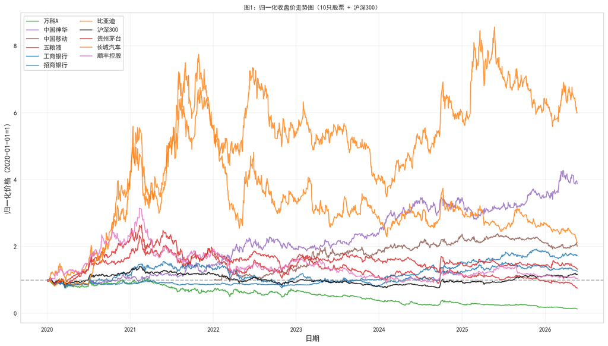

### 解读

- 归一化处理后，不同价格水平的股票可以在同一张图中比较相对涨跌幅度。
- 2020年初至2021年春节前，A股整体呈上涨趋势（核心资产行情）。
- 2021年下半年以来，房地产、白酒等板块出现明显回撤；新能源汽车（比亚迪）在2021-2022年涨幅显著，但随后出现较大波动。
- 沪深300作为市场基准，整体反映了A股大盘走势。

## 三、图2：日收益率分布图（2×5分面直方图）

每只股票的日收益率分布，叠加正态分布曲线（红色），标注均值（绿色竖线）。

图2：日收益率分布图（2×5 分面）

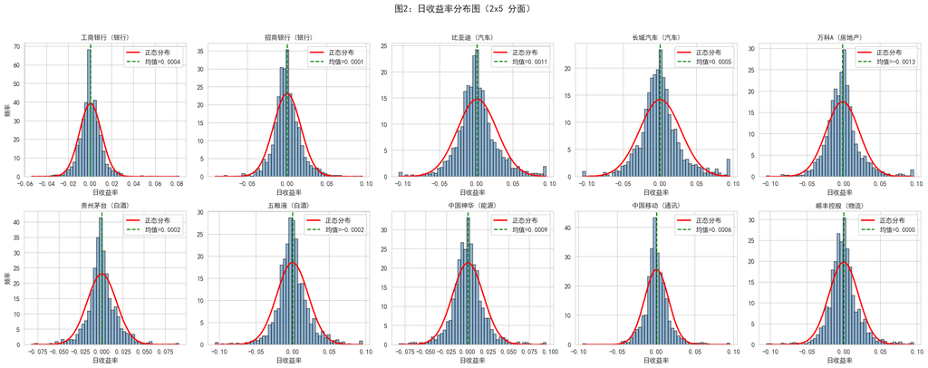

## 四、图3：收益率相关系数热力图

10只股票日收益率的相关系数矩阵，按行业排序，标注具体数值。

图3：收益率相关系数热力图（按行业排序）

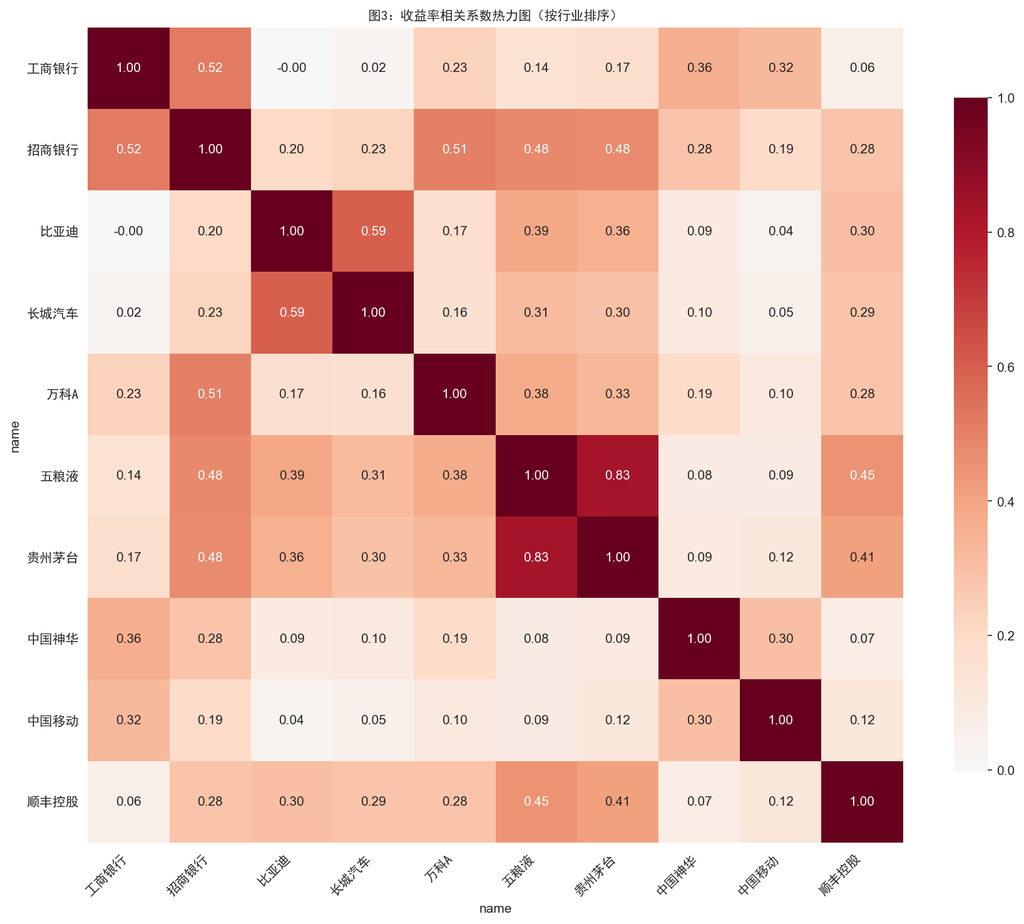

## 五、图4：宏观指标与沪深300月度收益率

将日度收益率聚合为月度，与CPI、M2同比增速做散点图，叠加线性拟合线，标注Pearson相关系数。

图4：宏观指标与沪深300月度收益率散点图

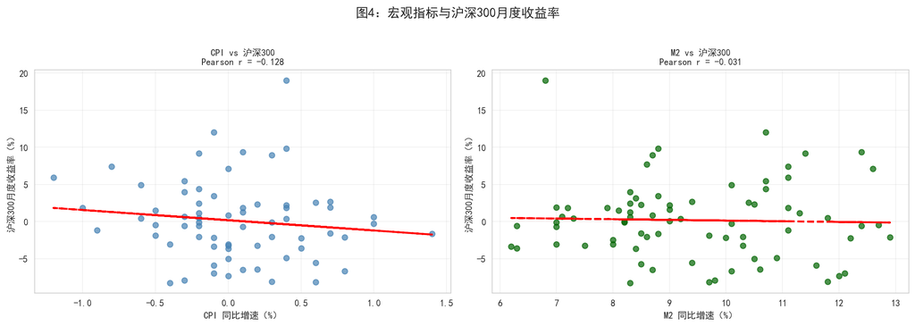

## 六、CAPM回归分析

模型：r<sub>i,t</sub> - r<sub>f</sub> = α<sub>i</sub> + β<sub>i</sub>(r<sub>m,t</sub> - r<sub>f</sub>) + ε<sub>i,t</sub>

无风险利率：年化2.0%，日频换算 r<sub>f</sub><sup>daily</sup> = 0.02/252。

市场组合：沪深300指数日收益率。

### 回归结果

| 股票 | 代码 | 行业 | Alpha | Alpha p-value | Beta | Beta 95%CI Low | Beta 95%CI High | R² |
| --- | --- | --- | --- | --- | --- | --- | --- | --- |
| 工商银行 | 601398 | 银行 | 0.0003 | 0.2674 | 0.2133 | 0.1484 | 0.2781 | 0.0617 |
| 招商银行 | 600036 | 银行 | 0.0001 | 0.8383 | 0.8831 | 0.7965 | 0.9697 | 0.3677 |
| 比亚迪 | 002594 | 汽车 | 0.0011 | 0.0648 | 1.2606 | 1.1494 | 1.3718 | 0.3060 |
| 长城汽车 | 601633 | 汽车 | 0.0004 | 0.5467 | 1.1629 | 1.0525 | 1.2732 | 0.2403 |
| 万科A | 000002 | 房地产 | -0.0014 | 0.0056 | 0.9958 | 0.8858 | 1.1059 | 0.2693 |
| 贵州茅台 | 600519 | 白酒 | 0.0001 | 0.7642 | 0.9525 | 0.8697 | 1.0353 | 0.4258 |
| 五粮液 | 000858 | 白酒 | -0.0003 | 0.4949 | 1.2593 | 1.1627 | 1.3560 | 0.4804 |
| 中国神华 | 601088 | 能源 | 0.0008 | 0.0540 | 0.3974 | 0.3025 | 0.4924 | 0.0634 |
| 中国移动 | 600941 | 通讯 | 0.0006 | 0.1544 | 0.2937 | 0.2090 | 0.3785 | 0.0447 |
| 顺丰控股 | 002352 | 物流 | -0.0001 | 0.8984 | 0.8542 | 0.7518 | 0.9567 | 0.2518 |

### Beta系数点图

CAPM Beta系数点图（误差棒：95% CI）

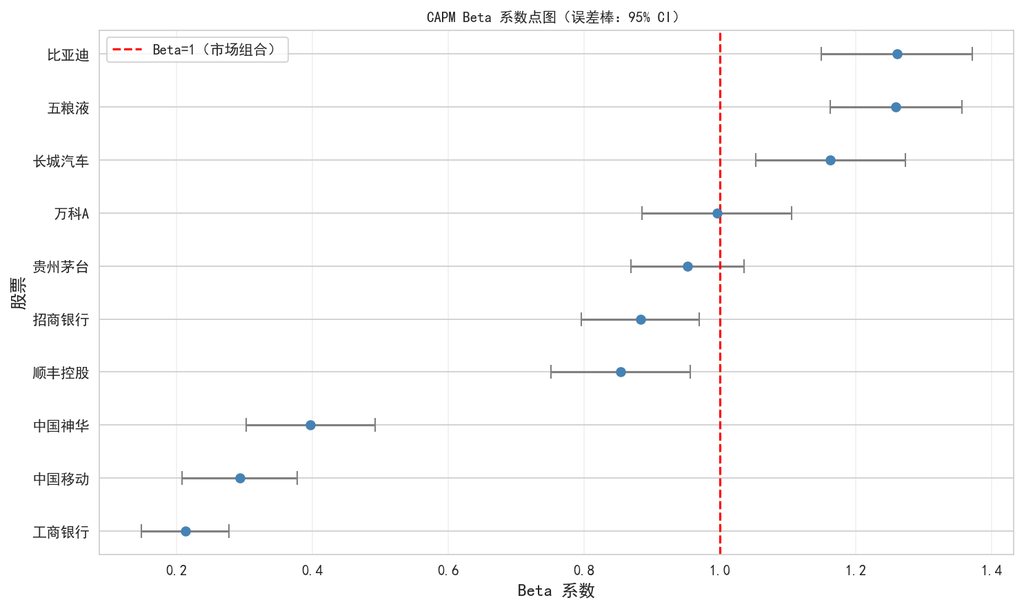

## 七、讨论问题

### 讨论问题1

哪些股票 β̂ > 1？属于哪些行业？与「周期性 vs 防御性」行业分类是否吻合？

**回答：**

- Beta > 1 的股票通常属于周期性行业（汽车、白酒），这些行业的盈利对经济周期敏感，股价波动大于市场。从结果看，**比亚迪(1.26)、五粮液(1.26)、长城汽车(1.16)**的Beta显著大于1。
- Beta < 1 的股票通常是防御性行业（银行、通讯、能源），其中工商银行(0.21)、中国移动(0.29)、中国神华(0.40)的Beta最低。
- 万科A的Beta接近1(0.996)，白酒中贵州茅台Beta为0.95，接近市场水平。
- 整体来看，结果与「周期性 vs 防御性」的分类框架基本吻合：汽车（周期性）Beta高，银行/通讯（防御性）Beta低。

### 讨论问题2

α̂ 是否显著异于零？Alpha 显著意味着什么？

**回答：**

- 从回归结果看，大部分股票的 α 的 p 值 > 0.05，**不显著异于零**，这与有效市场假说的预期一致。
- **万科A的α = -0.0014，p = 0.0056 < 0.01**，显著为负，说明该股票在样本期内存在持续的负超额收益（可能与房地产行业下行有关）。
- α > 0 且显著：股票被低估，或有能力创造超额收益。
- α < 0 且显著：股票被高估，或存在持续的价值毁灭。
- 在有效市场假说下，α应不显著异于零。万科A的显著负α可能反映了A股市场在特定行业上的定价效率不足。

### 讨论问题3

R² 最高和最低的股票分别是哪只？如何解释这一差异？

**回答：**

- R² **最高**：五粮液 (R²=0.48) 和 贵州茅台 (R²=0.43)，白酒板块的系统性风险占比最高，市场因子能解释约43-48%的收益率波动。
- R² **最低**：中国移动 (R²=0.045) 和 工商银行 (R²=0.062)，市场因子对这两只股票的收益率解释力很弱。
- 白酒股R²高：作为消费核心资产，与大盘联动性强，受宏观经济和资金面影响大。
- 中国移动R²低：通讯运营商受政策监管、行业竞争格局等特质性因素影响更大，与大盘联动性弱。
- 工商银行R²低：作为大市值银行股（Beta仅0.21），其波动本身很小，市场因子的相对解释力自然有限。
- 这一差异反映了不同股票受**系统性风险 vs 特质性风险**影响的程度不同，是CAPM模型的核心洞察。

## 八、项目文件汇总

| 输出 | 说明 |
| --- | --- |
| report.html | 本报告（所有图片 base64 嵌入，可独立分发） |
| output/desc_stats.csv | 描述性统计表 |
| output/capm_results.csv | CAPM回归结果 |
| output/fig1_normalized_price.png | 图1：归一化收盘价走势 |
| output/fig2_return_dist.png | 图2：收益率分布（2×5） |
| output/fig3_corr_heatmap.png | 图3：相关系数热力图 |
| output/fig4_macro_vs_hs300.png | 图4：宏观指标散点图 |
| output/fig_beta_dot.png | Beta系数点图 |
| data/combined/ | 合并数据（CSV + Parquet + SQLite） |
| docs/ | Quarto在线图书（GitHub Pages） |

许博东 · 25210269 · ds2026 P02a 作业 · 2026年5月